# Pre-processing & Deriving Conditional League Strengths

This code sets up our data where we get the domestic results + group stage results to fit into our BT model.

```r
ucl = readr::read_csv('../data/raw/UEFA_Champions_League_2020_Results_RAW.csv', show_col_types = FALSE)
ucl = ucl %>%
  mutate(
    Country_Away = str_extract(Away, "^[A-Za-z]{2,3}(?=\\s)"),
    Country_Home = str_extract(ucl$Home, " [a-z]{2,3}$")
  ) %>%
  mutate(
    Home = stringr::str_remove(Home, " [a-z]{2,3}$"),
    Away = str_remove(Away, "^[A-Za-z]{2,3}\\s+")
  )

uefa_playoff_teams = ucl %>%
  filter(Round %in% c("Round of 16", "Quarter-finals", "Semi-finals", "Final")) %>% select(Home, Away) %>%
  unlist(use.names = FALSE) %>% unique()

ucl_group <- ucl %>%
  filter(Round == "Group stage", HomeGoals != AwayGoals)

ucl_teams <- sort(unique(c(ucl_group$Home, ucl_group$Away)))

domestic_restricted <- all %>%
  mutate(Home = as.character(Home), Away = as.character(Away)) %>%
  filter(Home %in% ucl_teams | Away %in% ucl_teams) %>%
  filter(HomeGoals != AwayGoals) %>%
  filter(!stringr::str_detect(Round, "play-offs") | is.na(Round))


bt_dom <- domestic_restricted %>%
  transmute(
    home.team = Home,
    away.team = Away,
    home.win  = as.integer(HomeGoals > AwayGoals),
    away.win  = as.integer(AwayGoals > HomeGoals),
    Competition = "Domestic"
  )

bt_ucl <- ucl_group %>%
  transmute(
    home.team = Home,
    away.team = Away,
    home.win  = as.integer(HomeGoals > AwayGoals),
    away.win  = as.integer(AwayGoals > HomeGoals),
    Competition = "UCL"
  )

bt_all <- bind_rows(bt_dom, bt_ucl) %>%
  mutate(w = ifelse(Competition == "UCL", wt_ucl, wt_dom))

unik_teams_all <- sort(unique(c(bt_all$home.team, bt_all$away.team)))
bt_all <- bt_all %>%
  mutate(
    home.team = factor(home.team, levels = unik_teams_all),
    away.team = factor(away.team, levels = unik_teams_all)
  )
```

Fitting the BT model, we get:

```r
fit_all = BradleyTerry2::BTm(
  outcome = cbind(home.win, away.win),
  player1 = home.team,
  player2 = away.team,
  refcat = "Yenisey",
  data = bt_all
)

lambda_hat_combined <- BradleyTerry2::BTabilities(fit_all) %>%
  as.data.frame() %>%
  tibble::rownames_to_column("team") %>%
  arrange(desc(ability))

lambda_hat_combined = lambda_hat_combined %>%
  filter(team %in% uefa_playoff_teams)

lambda_hat_combined
```

| team | ability | s.e. |
| --- | --- | --- |
| Juventus | 22.95331 | 5376.529 |
| Liverpool | 22.93649 | 5376.529 |
| Barcelona | 22.88233 | 5376.529 |
| Manchester City | 22.40969 | 5376.529 |
| Napoli | 22.30021 | 5376.529 |
| Bayern Munich | 21.86009 | 5376.529 |
| Dortmund | 21.63099 | 5376.529 |
| Atlético Madrid | 21.57971 | 5376.529 |
| Atalanta | 21.24216 | 5376.529 |
| Valencia | 21.13025 | 5376.529 |

[output cut: 6 more lines]

Displaying our strengths in a graph:

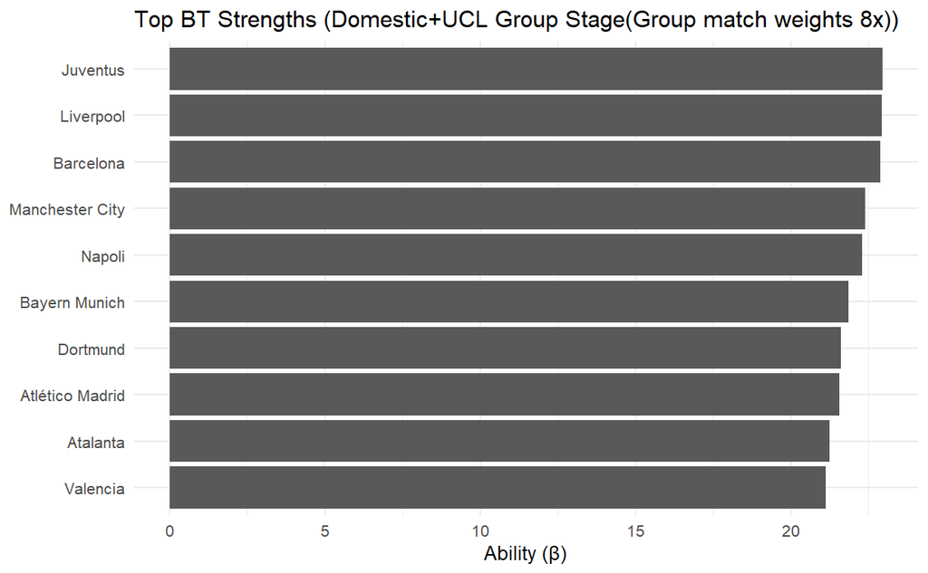

```r
lambda_hat_combined %>%
  slice_max(ability, n = 10) %>%
  ggplot(aes(reorder(team, ability), ability)) +
  geom_col() + coord_flip() +
  labs(title="Top BT Strengths (Domestic+UCL Group Stage(Group match weights 8x))", x=NULL, y="Ability (β)") +
  theme_minimal()
```

```r
NA
NA
```

Since the round of 16 for the Champions League Tournament had 2 legs before COVID officially shut down the tournament, we need to simulate both legs of the contest. However our Bradley-Terry model has limitations where it doesn’t predict score just the overall winner. For 2 leg contests, this shows a problem where aggregate score decides the winner. If both teams win one game, the Bradley Terry model doesn’t know who wins the whole round. Also, if one team wins marginally, and the other team wins by a lot, it still looks like 1 win and 1 loss to the Bradley Terry model. This is the reason that we want to get the scores of the matchups, so we shift for this round specifically to a Markov Chain model modeling states of the games using the Bradley-Terry strengths to simulate goal scores and state changes.

```r
total_gpm <- 2.7   # constant, estimated how many goals are scored per game
beta      <- 0.9   # how strongly BT ability difference tilts scoring share
hfa       <- 0.28  # home-field advantage in the scoring-share logit
et_scale  <- 0.75  # scoring slows in extra time
set.seed(25)

inv_logit <- function(x) 1/(1+exp(-x))

lambda_vec_raw <- setNames(lambda_hat_combined$ability, lambda_hat_combined$team)

get_lambda <- function(team) {#helper to get BT scores
  if (!is.na(team) && team %in% names(lambda_vec_raw)) {
    lambda_vec_raw[[team]]
  } else {
    0
  }
}

r16_ties <- tibble::tribble(
  ~tie_id, ~home_first_leg,     ~away_first_leg,
  "R16-1", "Atalanta",          "Valencia",
  "R16-2", "Dortmund",          "Paris S-G",
  "R16-3", "Atletico Madrid",   "Liverpool",
  "R16-4", "Tottenham",         "RB Leipzig",
  "R16-5", "Chelsea",           "Bayern Munich",
  "R16-6", "Napoli",            "Barcelona",
  "R16-7", "Real Madrid",       "Manchester City",
  "R16-8", "Lyon",              "Juventus"
)


r16_ties
```

| tie_id | home_first_leg | away_first_leg |
| --- | --- | --- |
| R16-1 | Atalanta | Valencia |
| R16-2 | Dortmund | Paris S-G |
| R16-3 | Atletico Madrid | Liverpool |
| R16-4 | Tottenham | RB Leipzig |
| R16-5 | Chelsea | Bayern Munich |
| R16-6 | Napoli | Barcelona |
| R16-7 | Real Madrid | Manchester City |
| R16-8 | Lyon | Juventus |

```r
NA
```

```r
sim_match_markov <- function(Home, Away, neutral=FALSE, allow_et=TRUE) {
  lamH <- get_lambda(Home); lamA <- get_lambda(Away)
  r_tot <- total_gpm / 90   # goal p per min
  s_home <- inv_logit(beta * (lamH - lamA) + ifelse(neutral, 0, hfa))
  pH <- r_tot * s_home
  pA <- r_tot * (1 - s_home)
  #first 90 mins
  gH <- 0L; gA <- 0L
  for (t in 1:90) {
    u <- runif(1)
    if (u < pH) gH <- gH + 1L else if (u < pH + pA) gA <- gA + 1L
  }

  #extra time - scale p to show scoring in ET
  if (allow_et && gH == gA) {
    pH_et <- pH * et_scale; pA_et <- pA * et_scale
    for (t in 1:30) {
      u <- runif(1)
      if (u < pH_et) gH <- gH + 1L else if (u < pH_et + pA_et) gA <- gA + 1L
    }
    if (gH == gA) {
      # Penalties
      base <- 0.76; tilt <- 0.02
      p_home <- max(min(base + tilt * tanh(lamH - lamA), 0.95), 0.55)
      p_away <- max(min(base - tilt * tanh(lamH - lamA), 0.95), 0.55)
      a <- b <- 0L
      for (i in 1:5) { a <- a + rbinom(1,1,p_home); b <- b + rbinom(1,1,p_away) }
      if (a != b) return(list(gH=gH, gA=gA, mode="PK", winner=ifelse(a>b,"home","away")))
      repeat {
        aa <- rbinom(1,1,p_home); bb <- rbinom(1,1,p_away)
        if (aa != bb) return(list(gH=gH, gA=gA, mode="PK", winner=ifelse(aa>bb,"home","away")))
      }
    }
    return(list(gH=gH, gA=gA, mode="ET", winner=ifelse(gH>gA,"home","away")))
  }
  list(gH=gH, gA=gA, mode="FT", winner=ifelse(gH>gA,"home","away"))
}
```

```r
sim_two_leg_markov <- function(A, B, away_goals_rule=TRUE) {
  # Leg 1: A home
  L1 <- sim_match_markov(A, B, neutral=FALSE, allow_et=FALSE)
  # Leg 2: B home
  L2 <- sim_match_markov(B, A, neutral=FALSE, allow_et=FALSE)

  aggA <- L1$gH + L2$gA
  aggB <- L1$gA + L2$gH
  if (aggA != aggB) return(list(winner=ifelse(aggA>aggB, A, B),
                                aggA=aggA, aggB=aggB, decided="AGG"))
  if (away_goals_rule) {
    A_away <- L2$gA; B_away <- L1$gA
    if (A_away != B_away)
      return(list(winner=ifelse(A_away>B_away, A, B),
                  aggA=aggA, aggB=aggB, decided="AWAY_GOALS"))
  }
  # ET in Leg 2 (B home)
  lamB <- get_lambda(B); lamA <- get_lambda(A)
  r_tot <- total_gpm / 90
  s_home <- inv_logit(beta * (lamB - lamA) + hfa)
  pH_et <- (r_tot * s_home) * et_scale
  pA_et <- (r_tot * (1 - s_home)) * et_scale
  gH_et <- 0L; gA_et <- 0L
  for (t in 1:30) {
    u <- runif(1)
    if (u < pH_et) gH_et <- gH_et + 1L else if (u < pH_et + pA_et) gA_et <- gA_et + 1L
  }
  aggA2 <- aggA + gA_et
  aggB2 <- aggB + gH_et
  if (aggA2 != aggB2)
    return(list(winner=ifelse(aggA2>aggB2, A, B),
                aggA=aggA2, aggB=aggB2, decided="ET"))

  # PKs
  base <- 0.76; tilt <- 0.02
  p_home <- max(min(base + tilt * tanh(lamB - lamA), 0.95), 0.55)
  p_away <- max(min(base - tilt * tanh(lamB - lamA), 0.95), 0.55)
  a <- b <- 0L
  for (i in 1:5) { a <- a + rbinom(1,1,p_home); b <- b + rbinom(1,1,p_away) }
  if (a != b) return(list(winner=ifelse(a>b, B, A),
                          aggA=aggA2, aggB=aggB2, decided="PK"))
  repeat {
    aa <- rbinom(1,1,p_home); bb <- rbinom(1,1,p_away)
    if (aa != bb) return(list(winner=ifelse(aa>bb, B, A),
                              aggA=aggA2, aggB=aggB2, decided="PK"))
  }
}
```

```r
simulate_r16_mc <- function(N=5000, away_goals_rule=TRUE) {
  purrr::map_dfr(seq_len(nrow(r16_ties)), function(i) {
    A <- r16_ties$home_first_leg[i]
    B <- r16_ties$away_first_leg[i]
    winsA <- 0L; sumAggA <- 0; sumAggB <- 0
    for (k in 1:N) {
      out <- sim_two_leg_markov(A, B, away_goals_rule=away_goals_rule)
      if (out$winner == A) winsA <- winsA + 1L
      sumAggA <- sumAggA + out$aggA
      sumAggB <- sumAggB + out$aggB
    }
    pA <- winsA / N
    tibble::tibble(
      tie_id = r16_ties$tie_id[i],
      team_A = A, team_B = B,
      p_adv_A = pA,
      p_adv_B = 1 - pA,
      se_A = sqrt(pA*(1-pA)/N),
      mean_agg_A = sumAggA / N,
      mean_agg_B = sumAggB / N
    )
  }) %>% arrange(tie_id)
}
```

From our games, we decided to run a markov simulation to get the probability a team will win out of N times, which also gets the average aggregate scores between two teams. This shows us in a real simulation how many times a team would be expected to win based on our BT strengths, and the matchup.

```r
N <- 5000
r16_results <- simulate_r16_mc(N=N, away_goals_rule=TRUE)
print(r16_results)
```

| tie_id | team_A | team_B | p_adv_A | p_adv_B | se_A | mean_agg_A | mean_agg_B |
| --- | --- | --- | --- | --- | --- | --- | --- |
| R16-1 | Atalanta | Valencia | 0.5416 | 0.4584 | 0.0070465515 | 2.8542 | 2.5860 |
| R16-2 | Dortmund | Paris S-G | 0.8040 | 0.1960 | 0.0056139825 | 3.6750 | 1.7242 |
| R16-3 | Atletico Madrid | Liverpool | 0.0008 | 0.9992 | 0.0003998400 | 0.0000 | 5.3918 |
| R16-4 | Tottenham | RB Leipzig | 0.3068 | 0.6932 | 0.0065218672 | 2.1318 | 3.2668 |
| R16-5 | Chelsea | Bayern Munich | 0.1854 | 0.8146 | 0.0054959410 | 1.7512 | 3.7498 |
| R16-6 | Napoli | Barcelona | 0.2702 | 0.7298 | 0.0062799994 | 2.0238 | 3.3870 |
| R16-7 | Real Madrid | Manchester City | 0.0830 | 0.9170 | 0.0039015638 | 1.1944 | 4.2512 |
| R16-8 | Lyon | Juventus | 0.0044 | 0.9956 | 0.0009360171 | 0.2352 | 5.2124 |

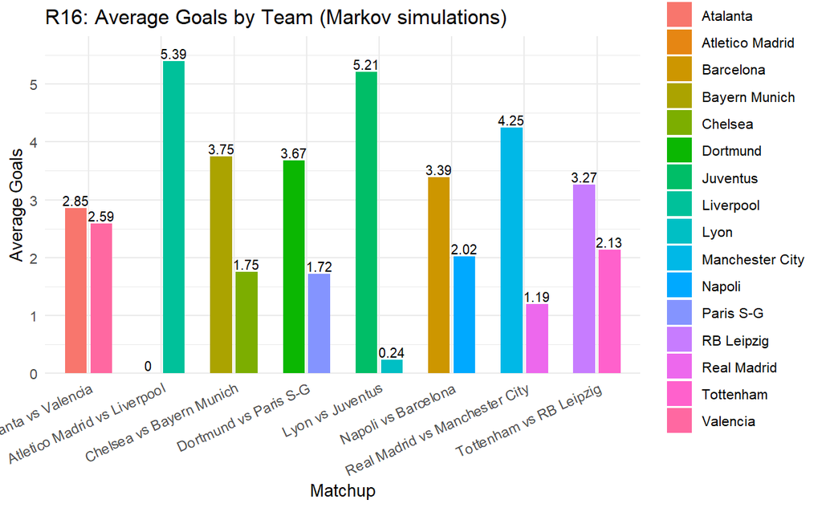

```r
r16_long <- r16_results %>%
  mutate(matchup = paste(team_A, "vs", team_B)) %>%           # <-- create it
  pivot_longer(
    cols = c(mean_agg_A, mean_agg_B),
    names_to = "which_team",
    values_to = "mean_goals"
  ) %>%
  mutate(team = if_else(which_team == "mean_agg_A", team_A, team_B)) %>%
  select(tie_id, matchup, team, mean_goals)



# Plot: side-by-side bars per matchup
ggplot(r16_long, aes(x = matchup, y = mean_goals, fill = team)) +
  geom_col(position = position_dodge(width = 0.7), width = 0.6) +
  geom_text(aes(label = round(mean_goals, 2)),
            position = position_dodge(width = 0.7),
            vjust = -0.25, size = 3) +
  scale_y_continuous(expand = expansion(mult = c(0, 0.08))) +
  labs(title = "R16: Average Goals by Team (Markov simulations)",
       x = "Matchup", y = "Average Goals", fill = "Team") +
  theme_minimal() +
  theme(axis.text.x = element_text(angle = 25, hjust = 1))
```

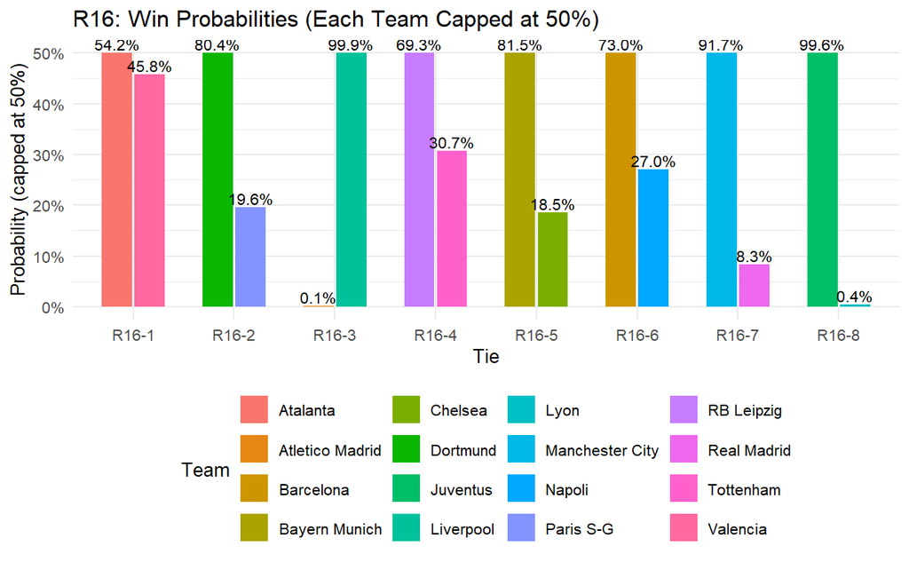

```r
r16_long <- r16_results %>%
  transmute(
    tie_id,
    team_A, team_B,
    p_A = p_adv_A,
    p_B = p_adv_B
  ) %>%
  pivot_longer(cols = c(team_A, team_B),
               names_to = "side", values_to = "team") %>%
  mutate(prob = ifelse(side == "team_A", p_A, p_B)) %>%
  mutate(prob_cap50 = pmin(prob, 0.5),
         label_full = sprintf("%.1f%%", 100 * prob))

# Plot: two bars per tie, capped at 50%
ggplot(r16_long, aes(x = tie_id, y = prob_cap50, fill = team)) +
  geom_col(position = position_dodge(width = 0.65), width = 0.6) +
  geom_text(aes(label = label_full),
            position = position_dodge(width = 0.65),
            vjust = -0.25, size = 3.2) +
  scale_y_continuous(labels = percent_format(accuracy = 1),
                     limits = c(0, 0.5), breaks = seq(0, 0.5, by = 0.1)) +
  labs(
    title = "R16: Win Probabilities (Each Team Capped at 50%)",
    x = "Tie",
    y = "Probability (capped at 50%)",
    fill = "Team"
  ) +
  theme_minimal() +
  theme(legend.position = "bottom")
```

```r
#helper to simulate match using markov function
play_neutral <- function(A, B) {
  out <- sim_match_markov(Home = A, Away = B, neutral = TRUE, allow_et = TRUE)
  if (out$winner == "home") A else B
}

simulate_tournament_once <- function(r16_results) {
  # 1) Sample R16 winners from p_adv_A
  # r16_results: tie_id, team_A, team_B, p_adv_A, p_adv_B, ...
  winners_r16 <- r16_results %>%
    arrange(tie_id) %>%                 # ensure R16-1,...,R16-8 in order
    mutate(
      A_wins = runif(n()) < p_adv_A,
      winner = ifelse(A_wins, team_A, team_B)
    )

  # 2) Build QF bracket from these winners (fixed structure)
  qf1_A <- winners_r16$winner[winners_r16$tie_id == "R16-1"]
  qf1_B <- winners_r16$winner[winners_r16$tie_id == "R16-2"]

  qf2_A <- winners_r16$winner[winners_r16$tie_id == "R16-3"]
  qf2_B <- winners_r16$winner[winners_r16$tie_id == "R16-4"]

  qf3_A <- winners_r16$winner[winners_r16$tie_id == "R16-5"]
  qf3_B <- winners_r16$winner[winners_r16$tie_id == "R16-6"]

  qf4_A <- winners_r16$winner[winners_r16$tie_id == "R16-7"]
  qf4_B <- winners_r16$winner[winners_r16$tie_id == "R16-8"]

  # 3) QFs (single-leg, neutral)
  qf1_w <- play_neutral(qf1_A, qf1_B)
  qf2_w <- play_neutral(qf2_A, qf2_B)
  qf3_w <- play_neutral(qf3_A, qf3_B)
  qf4_w <- play_neutral(qf4_A, qf4_B)

  # 4) SFs
  sf1_w <- play_neutral(qf1_w, qf2_w)
  sf2_w <- play_neutral(qf3_w, qf4_w)

  # 5) Final
  champion <- play_neutral(sf1_w, sf2_w)

  list(
    champion = champion,
    final_A = sf1_w,
    final_B = sf2_w
  )
}

simulate_tournament_field <- function(M = 5000, r16_results) {
  champs   <- character(M)
  finals_A <- character(M)
  finals_B <- character(M)

  for (m in seq_len(M)) {
    sim <- simulate_tournament_once(r16_results)
    champs[m]   <- sim$champion
    finals_A[m] <- sim$final_A
    finals_B[m] <- sim$final_B
  }

  sims <- tibble::tibble(
    sim_id  = seq_len(M),
    champion = champs,
    final_A  = finals_A,
    final_B  = finals_B
  )

  # 1) Title probabilities
  title_probs <- sims %>%
    dplyr::count(champion, name = "titles") %>%
    dplyr::mutate(
      total_sims = sum(titles),
      pct = titles / total_sims
    ) %>%
    dplyr::arrange(dplyr::desc(pct))

  # 2) Final matchup probabilities (treat matchups as unordered pairs)
  final_matchups <- sims %>%
    dplyr::mutate(
      team1 = pmin(final_A, final_B),
      team2 = pmax(final_A, final_B)
    ) %>%
    dplyr::count(team1, team2, name = "n") %>%
    dplyr::mutate(
      total_sims = sum(n),
      pct = n / total_sims
    ) %>%
    dplyr::arrange(dplyr::desc(pct))

  list(
    title_probs    = title_probs,
    final_matchups = final_matchups,
    raw_sims       = sims
  )
}

set.seed(25)
M <- 5000
tourn_out <- simulate_tournament_field(M, r16_results)

tourn_out$title_probs       # P(team wins tournament)
```

| champion | titles | total_sims | pct |
| --- | --- | --- | --- |
| Liverpool | 2203 | 5000 | 0.4406 |
| Juventus | 1254 | 5000 | 0.2508 |
| Barcelona | 833 | 5000 | 0.1666 |
| Manchester City | 290 | 5000 | 0.0580 |
| Dortmund | 134 | 5000 | 0.0268 |
| Napoli | 132 | 5000 | 0.0264 |
| Bayern Munich | 74 | 5000 | 0.0148 |
| Atalanta | 28 | 5000 | 0.0056 |
| Valencia | 22 | 5000 | 0.0044 |
| RB Leipzig | 18 | 5000 | 0.0036 |

[output cut: 3 more lines]

```r
tourn_out$final_matchups    # P(final is Team1 vs Team2)
```

| team1 | team2 | n | total_sims | pct |
| --- | --- | --- | --- | --- |
| Juventus | Liverpool | 1641 | 5000 | 0.3282 |
| Barcelona | Liverpool | 1203 | 5000 | 0.2406 |
| Liverpool | Manchester City | 587 | 5000 | 0.1174 |
| Liverpool | Napoli | 270 | 5000 | 0.0540 |
| Dortmund | Juventus | 241 | 5000 | 0.0482 |
| Bayern Munich | Liverpool | 224 | 5000 | 0.0448 |
| Barcelona | Dortmund | 188 | 5000 | 0.0376 |
| Atalanta | Juventus | 80 | 5000 | 0.0160 |
| Dortmund | Manchester City | 80 | 5000 | 0.0160 |
| Juventus | RB Leipzig | 58 | 5000 | 0.0116 |

[output cut: 27 more lines]

## References

Deshpande, Sameer. 2025. “Lecture 12: Bradley-Terry Models.” University of Wisconsin-Madison. https://skdeshpande91.github.io/stat479_fall2025/lectures/lecture12.html.

[^1]: Members from the following domestic leagues took part in the 2019-20 UEFA Champions League group stage: *Austrian Football Bundesliga, Belgian Pro League, Croatian Football League, Czech First League, English Premier League, French Ligue 1, German Fusball Bundesliga, Greek Super League, Italian Serie A, Dutch Eredivise, Portugese Premeira Liga, Russian Premier League, Serbian SuperLiga, Spanish La Liga, Turkish Super Lig, Ukrainian Premier League*
[^2]: Specific links and FBRef pages used can be found in the *GettingRawMatchupData.Rmd* notebook.
[^3]: https://en.wikipedia.org/wiki/UEFA_coefficient
[^4]: https://en.wikipedia.org/wiki/2018%E2%80%9319_Super_League_Greece#League_table